# Bayesian Model for modeling Women And Girls Violence dataset

Lucas Bianchi

2022-11-30

# Women And Girls Violence

This dataset aggregates agreement with key questions across gender, education level and many other socioeconomic variables from 70 different countries.

The data was collected as part of the Demographic and Health Surveys (DHS) program, which exists to advance the global understanding of health and population trends in developing countries.

## Importing packages

In the chunk below we are importing the packages necessary for running our analysis. Since we may have not installed them before, it is important to install them, if needed. The *pacman* package takes care of that for us.

```r
r_pkgs <- c('tidyverse', 'lubridate', 'ggplot2', 'janitor',
'rnaturalearth', 'rnaturalearthdata',
'ggspatial', 'sf', 'rstanarm', 'bayesplot', 'sjPlot')

# Instala o pacote pacman se ele não estiver instalado:
if(!"pacman" %in% rownames(installed.packages())) install.packages("pacman")
pacman::p_load(char = r_pkgs)
```

If you already downloaded the dataset, make sure it is in your project, if so, let`s import it.

```r
data = read.csv("violence_data.csv") %>%
  mutate(
    year = year(dmy(Survey.Year))
  ) %>%
  clean_names() %>%
  dplyr::select(-c(survey_year, record_id)) %>%
  mutate(
    question = str_to_sentence(gsub("\\... ", "", question)),
    question = gsub("If she ", "If she\n", question),
    gender = ifelse(gender == "F", "Female", "Male"),
    gender = factor(gender, levels = c("Female", "Male"))
  )
```

It the chunk below we are generating maps for each year and for each violence. Since this may take a while to run, it is written around an *if statement*.

```r
generate_maps = FALSE
if(generate_maps == TRUE){
  world <- ne_countries(scale = "medium", returnclass = "sf") %>%
    mutate(
      brk_name = case_when(
        brk_name == "Democratic Republic of the Congo" ~ "Congo Democratic Republic",
        brk_name == "Republic of Congo" ~ "Congo",
        brk_name == "Côte d'Ivoire" ~ "Cote d'Ivoire",
        brk_name == "Dominican Rep." ~ "Dominican Republic",
        brk_name == "Kyrgyzstan" ~ "Kyrgyz Republic",
        brk_name == "Swaziland" ~ "Eswatini",
        TRUE ~ brk_name
      )
    ) %>%
    # filter(brk_name %in% unique(data$country)) %>%
    rename(country = brk_name) %>%
    dplyr::select(country, continent, economy, income_grp)

  data_age <- data %>%
    filter(demographics_question == "Age")

  data_expanded_grid <- expand.grid(
    country = unique(world$country),
    gender =  unique(data$gender),
    year = unique(data$year),
    question = unique(data$question)
  ) %>%
    mutate(
      id = paste0(country, "_", gender, "_", question, "_", year)
    )

  data_expanded_grid <- data_expanded_grid %>%
    left_join(world, by = "country")

  for(i in unique(data_age$demographics_response)){

    data_temp <- data_age %>%
      filter(demographics_response == i) %>%
      group_by(country, gender, question, year) %>%
      mutate(
        id = paste0(country, "_", gender, "_", question, "_", year),
        value = sum(value, na.rm = T)
      ) %>%
      distinct(id, .keep_all = T) %>%
      ungroup() %>%
      arrange(country, gender, question, year) %>%
      dplyr::select(-c(demographics_question, demographics_response))

    data_temp2 <- data_expanded_grid %>%
      left_join(data_temp %>%
                  dplyr::select(-c(gender, year, question, country)), by = "id") %>%
      relocate(geometry, .after = "year")  %>%
      replace_na(list(value = 0)) %>%
      st_as_sf()

    for(j in sort(unique(data_temp2$year))){

      data_temp3 <- data_temp2 %>%
        filter(year == j)

      map_result <- ggplot() +
        geom_sf(data = world, colour = "black", size = 0.5, show.legend = F) +
        geom_sf(data = data_temp3, aes(fill = value)) +
        theme_bw() +
        theme(plot.title = element_text(size = 40, face = "bold"),
              text = element_text(size = 30),
              axis.title = element_text(face="bold"),
              axis.text.x = element_text(size = 20),
              axis.text.y = element_text(size = 20),
              panel.grid.minor = element_blank(),
              legend.title = element_text(face = "bold", size = 30),
              legend.text = element_text(size = 30),
              legend.justification = "right",
              panel.background = element_rect(fill = "aliceblue"),
              strip.text.x = element_text(face = "bold", size = 26),
              strip.background = element_rect(
                color="black", fill="#f0f0f0", linewidth=1.5, linetype="solid"
              )
        ) +
        labs(
          title = paste0("Sociodemographic Questions by Sex, Age: ",i, " (", j,")"),
          x = NULL, y = NULL
        ) +
        scale_fill_gradient2(
          low = "white", mid = "yellow",
          high = "red", space ="Lab" ,
          midpoint = 50,
          limits = c(0, 100),
          breaks = seq(0, 100, 10)
        ) +
        guides(fill = guide_colourbar(title = "% Agreement", barwidth = 2, barheight = 40)) +
        facet_wrap(~question*gender, ncol = 2,
                   labeller = label_wrap_gen(width=120))

      ggsave(filename = paste0("images/map_sexage",i,"_",j,".png"),
             plot =  map_result, dpi = 300,
             height = 80, width = 62, units = "cm")
    }

  }
}
```

```r
if(generate_maps == TRUE){
  data_descriptive <- data %>%
    dplyr::select(-year) %>%
    group_by(gender, demographics_question, demographics_response, question) %>%
    summarise(
      mean = mean(value, na.rm = T),
      sd = sd(value, na.rm = T),
      min = min(value, na.rm = T),
      max = max(value, na.rm = T),
      median = median(value, na.rm = T)
    )

  for(i in unique(data_descriptive$demographics_question)){
    # i = "Age"
    data_temp <- data_descriptive %>%
      filter(demographics_question == i)

    g_temp <- data_temp %>%
      ggplot(aes(x = demographics_response, y = mean, fill = gender)) +
      geom_col(position = "dodge") +
      theme_bw() +
      theme(plot.title = element_text(size = 20, face = "bold"),
            text = element_text(size = 12),
            axis.title = element_text(face="bold"),
            axis.text.x = element_text(size = 12),
            axis.text.y = element_text(size = 12),
            panel.grid.minor = element_blank(),
            legend.title = element_text(face = "bold", size = 12),
            legend.text = element_text(size = 12),
            legend.justification = "right",
            panel.background = element_rect(fill = "aliceblue"),
            strip.text.x = element_text(face = "bold", size = 12),
            strip.background = element_rect(
              color="black", fill="#f0f0f0", linewidth=1.5, linetype="solid"
            )
      ) +
      labs(title = str_to_title(i), x = "", y = "Mean") +
      facet_wrap(~question, ncol = 2)

    print(g_temp)

  }
}
```

```r
# Maps
if(generate_maps == TRUE){
  data_map <- data %>%
    group_by(country, gender, question) %>%
    summarise(
      mean = mean(value, na.rm = T),
      sd = sd(value, na.rm = T),
      min = min(value, na.rm = T),
      max = max(value, na.rm = T),
      median = median(value, na.rm = T)
    ) %>%
    ungroup() %>%
    mutate(
      id = paste0(country, "_", gender, "_", question)
    )

  world <- ne_countries(scale = "medium", returnclass = "sf") %>%
    mutate(
      brk_name = case_when(
        brk_name == "Democratic Republic of the Congo" ~ "Congo Democratic Republic",
        brk_name == "Republic of Congo" ~ "Congo",
        brk_name == "Côte d'Ivoire" ~ "Cote d'Ivoire",
        brk_name == "Dominican Rep." ~ "Dominican Republic",
        brk_name == "Kyrgyzstan" ~ "Kyrgyz Republic",
        brk_name == "Swaziland" ~ "Eswatini",
        TRUE ~ brk_name
      )
    ) %>%
    # filter(brk_name %in% unique(data$country)) %>%
    rename(country = brk_name) %>%
    dplyr::select(country)

  data_expanded_grid <- expand.grid(
    country = unique(world$country),
    gender =  unique(data_map$gender),
    question = unique(data_map$question)
  ) %>%
    mutate(
      id = paste0(country, "_", gender, "_", question)
    )

  data_expanded_grid <- data_expanded_grid %>%
    left_join(world, by = "country")

  data_temp2 <- data_expanded_grid %>%
    left_join(data_map %>%
                dplyr::select(-c(gender,question, country)), by = "id") %>%
    relocate(geometry, .after = "median")  %>%
    replace_na(list(
      mean = 0,
      sd = 0,
      min = 0,
      max = 0,
      median = 0)) %>%
    st_as_sf()

  map_result <- ggplot() +
    geom_sf(data = world, colour = "black", size = 0.5, show.legend = F) +
    geom_sf(data = data_temp2, aes(fill = median)) +
    theme_bw() +
    theme(plot.title = element_text(size = 40, face = "bold"),
          text = element_text(size = 30),
          axis.title = element_text(face="bold"),
          axis.text.x = element_text(size = 20),
          axis.text.y = element_text(size = 20),
          panel.grid.minor = element_blank(),
          legend.title = element_text(face = "bold", size = 30),
          legend.text = element_text(size = 30),
          legend.justification = "right",
          panel.background = element_rect(fill = "aliceblue"),
          strip.text.x = element_text(face = "bold", size = 26),
          strip.background = element_rect(
            color="black", fill="#f0f0f0", linewidth=1.5, linetype="solid"
          )
    ) +
    labs(
      title = paste0("Sociodemographic Questions by Sex"),
      x = NULL, y = NULL
    ) +
    scale_fill_gradient2(
      low = "white", mid = "yellow",
      high = "red", space ="Lab" ,
      midpoint = 50,
      limits = c(0, 100),
      breaks = seq(0, 100, 10)
    ) +
    guides(fill = guide_colourbar(title = "% Agreement", barwidth = 2, barheight = 40)) +
    facet_wrap(~question*gender, ncol = 4,
               labeller = label_wrap_gen(width=120))

  ggsave(filename = paste0("images/map_sex.png"),
         plot =  map_result, dpi = 300,
         height = 80, width = 80, units = "cm")
}
```

# Bayesian Model

```r
data_model <- data %>%
  group_by(gender, demographics_question, demographics_response, question) %>%
  summarise(
    median = median(value, na.rm = T)/100
  ) %>%
  ungroup()
```

```
## 'demographics_response'. You can override using the `.groups` argument.
```

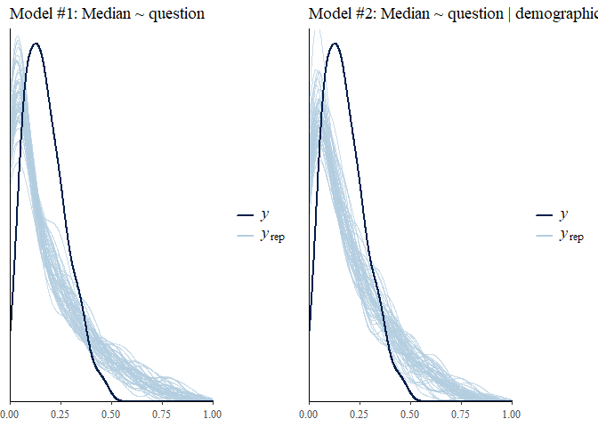

```r
theme_set(bayesplot::theme_default())

fit1 <- stan_betareg(median ~ question, data = data_model, link = "logit", link.phi = "log",
                     cores = 2, seed = 12345)

fit2 <- stan_betareg(median ~ question | demographics_response, data = data_model, link = "logit", link.phi = "log",
                     cores = 2, seed = 12345)


bayesplot_grid(
  pp_check(fit1), pp_check(fit2),
  xlim = c(0,1),
  ylim = c(0,4),
  titles = c("Model #1: Median ~ question", "Model #2: Median ~ question | demographics response"),
  grid_args = list(ncol = 2)
)
```

```r
loo1 <- loo(fit1)
loo2 <- loo(fit2)
loo_compare(loo1, loo2)
```

```
##      elpd_diff se_diff
## fit2   0.0       0.0
## fit1 -43.0       7.9
```

According to the results in the table above, evaluating the expected log predictive distribution, the second of the two models is preferred. The table below presents the coeficients for the Beta Bayesian model.

```r
prior_summary(fit2)
```

```
## Priors for model 'fit2'
## ------
## Intercept (after predictors centered)
##  ~ normal(location = 0, scale = 2.5)
##
## Coefficients
##  ~ normal(location = [0,0,0,...], scale = [2.5,2.5,2.5,...])
##
## Intercept_z (after predictors centered)
##  ~ normal(location = 0, scale = 2.5)
##
## Coefficients_z
##  ~ normal(location = [0,0,0,...], scale = [2.5,2.5,2.5,...])
## ------
## See help('prior_summary.stanreg') for more details
```

```r
tab_model(fit2, string.pred = "Coeffcient")
```

|  | median |  |
| --- | --- | --- |
| Coeffcient | Estimates | CI (95%) |
| (Intercept) | 0.50 | 0.46 – 0.55 |
| questionIf she argues with him | 0.41 | 0.36 – 0.47 |
| questionIf she burns the food | 0.17 | 0.14 – 0.20 |
| questionIf she goes out without telling him | 0.45 | 0.39 – 0.52 |
| questionIf she neglects the children | 0.59 | 0.52 – 0.67 |
| questionIf she refuses to have sex with him | 0.22 | 0.19 – 0.26 |
| (phi)_(Intercept) | 109.11 | 48.94 – 225.46 |
| (phi)_demographics_response25-34 | 0.59 | 0.19 – 1.78 |
| (phi)_demographics_response35-49 | 0.38 | 0.12 – 1.11 |
| (phi)_demographics_responseEmployed for cash | 0.60 | 0.19 – 1.80 |
| (phi)_demographics_responseEmployed for kind | 0.46 | 0.15 – 1.34 |
| (phi)_demographics_responseHigher | 0.05 | 0.02 – 0.14 |
| (phi)_demographics_responseMarried or living together | 0.44 | 0.15 – 1.26 |
| (phi)_demographics_responseNever married | 2.08 | 0.66 – 6.28 |
| (phi)_demographics_responseNo education | 0.24 | 0.08 – 0.72 |
| (phi)_demographics_responsePrimary | 0.56 | 0.19 – 1.65 |
| (phi)_demographics_responseRural | 0.49 | 0.15 – 1.42 |
| (phi)_demographics_responseSecondary | 0.74 | 0.22 – 2.22 |
| (phi)_demographics_responseUnemployed | 0.51 | 0.17 – 1.51 |
| (phi)_demographics_responseUrban | 0.27 | 0.09 – 0.78 |
| (phi)_demographics_responseWidowed, divorced, separated | 2.05 | 0.62 – 6.50 |
| N <sub>demographics_response</sub> | 15 |  |
| Observations | 180 |  |